# Project: Wrangling and Analyze We Rate Dog Data

#### Questions on Analysis :

1. Determine the aggregate of the ratings, retweet, and favorite counts
2. Name of the dog with the highest rating and the day and time of the tweet
3. Name of the dog with the highest retweets and the day and time of the tweet
4. Name of the dog with the highest likes and the day and time of the tweet
5. Percentages contribution of the different tweet sources
6. Number of tweets per day
7. Percentages contribution of the different numbers of image posted

#### Analysis Report:

The rating ranged from 0 to 1776, the mean, median and mode were 11.7, 11.0 and 12.0 respectively. The number of retweets and likes for each dog ranged from 26 to 79,515 and 81 to 132810 respectively. The mean and median values were 2792.2 and 1367.0 for the retweets and, 8976.1 and 4149.0 for the likes.

Atticus is the most rated dog, and tweet was made on the 4th of July, 2016 at 15:00:45 O'clock. The names of the dogs with most retweets and likes were not provided however, they were tweeted on the 18th of June, 2016 and 21st of January, 2017 at about the same time, 18:26:18 and 18:26:02 respectively.

Ninty-eight percent of the tweets were from iphone. The maximum number of tweets per day was 26, and this was only archived twice, on the 28th and 29th of November, 2015. About 86% of the tweets contains only one image of the dog.

#### Questions on Visualization:

1. Boxplot for the ratings
2. Plot the boxplot again after eliminating outliers
3. Relationship between retweet counts and ratings
4. Relationship between favorite counts and ratings
5. Relationship between favorite counts and retweet counts
6. Relationship between number of image posted and retweets
7. Bar chart of number of images posted
8. Bar chart of sources of tweets

#### Visualization Report:

The boxplot showed the rating is positively skewed. Exploratory analysis was done to elimate dogs with ratings outside the interquatile ranges (25th and 75th percentiles). There is no correlation between the ratings and retweets, same thing applicable to ratings and likes, number of images and number of retweets(favorite counts). However, there is a positive correlation between number of retweets and number of likes.

```python
# import libraries
import pandas as pd
import matplotlib.pyplot as plt
import seaborn as sns
%matplotlib inline

# load data
df = pd.read_csv('twitter_archive_master.csv')
```

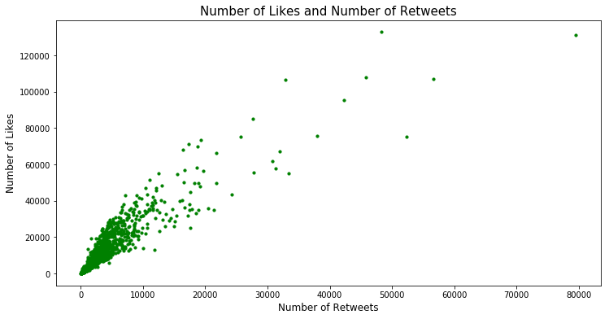

```python
#Relationship between favorite counts and retweet counts
df.plot.scatter(x='retweet_count',y='favorite_count',s=10,c='green',figsize=(12,6));

# chart labels
plt.xlabel('Number of Retweets', fontsize=12);
plt.ylabel('Number of Likes', fontsize=12)
plt.title('Number of Likes and Number of Retweets', fontsize=15);
```